# Engineering Knowledge from the Published Medical Literature

#### Stephen Howe

##### 30 March 2019

##### Northeastern University College of Professional Studies

##### ALY6980 Winter 2019

# Introduction

“Literature-based Discovery (LBD) seeks to discover new knowledge from existing literature in an automated or semi-automated way. Scientific literature is growing at an exponential rate causing researchers to become increasingly specialized, and making it difficult for researchers to stay current in even their narrow discipline. There is too much information for anyone to read, much less understand” (Henry & McInnes, 2017).

The analysis presented in this R Notebook is directed at the scientific researcher looking to gain new insights from a set of scientific literature. In this notebook, I apply various text-analysis, text-mining, and natural language processing techniques to a set of data describing a small set of published scientific articles on Castleman Disease. The goal here is to demonstrate the kinds of information and insights that can be extracted from published works metadata. The objective here is one of efficiency. For a publishing industry that is still built around single-threaded, human-readable documents, and for the scientific researcher aiming to distill learnings from the published body of liteature so that they can move on to their own, core research, the benefit of (semi-)automated knowledge discovery is huge.

The analysis below is question-driven and provides both the answers to these questions and the code used to derive those answers. For a more thorough discussion and presentation of the industry context, problem space, problem statements, and hypotheses behind this analysis, please refer to the accompanying presentation, *Engineering Knowledge from the Published Medical Literature: Applying Natural Language Processing Methods to a Corpus of Castleman Disease Articles.*

# The Data

Data for this analysis has been sourced from the MEDLINE/Pubmed repository of published articles in the bioscience domain. Pubmed was created and is maintained by the National Library of Medicine. The complete dataset of 29 million articles can be downloaded for free directly from the [library](https://www.nlm.nih.gov/databases/download/pubmed_medline.html). For this analysis, the set of articles is limited to those specifically on Castleman Disease. This set of articles was obtained by searching on the [Pubmed search page](https://www.ncbi.nlm.nih.gov/pubmed/) using the search query `"Castleman Disease" [MeSH Terms]`. This search query relies on MEDLINE’s authoritative ontology of medical subject headings (MeSH) to isolate the relevant articles. This query returns a set of 2417 articles (as of March 11, 2019) that was then downloaded as an XML file. A description of the MEDLINE XML DTD and each XML element can be found on the [MEDLINE/Pubmed XML Data Elements](https://www.nlm.nih.gov/bsd/licensee/data_elements_doc.html) webpage.

# R Packages and Data

The libraries required for this analysis are loaded next and the XML file is parsed into a variable. I also create a list of the PMIDs used to identify each article in this XML file. PMID is MEDLINE’s standard identifier for a published article. It is unique.

```r
#libraries ----
Sys.time()
```

```
[1] "2019-03-29 21:24:45 EDT"
```

```r
library(XML) #xml parsing
library(xml2) #xml parsing
library(dplyr) #data manipulation and cleaning
library(plyr) #data maniupulation and cleaning
library(ggplot2) #data visualization
library(rworldmap) #world map visulization
library(tm) #text mining
library(topicmodels) #LDA topic modeling
library(networkD3) #network graphs
library(igraph) #network graphs
library(viridis) #color
library(textmineR) #text mining: LDA, LSA, Hierarchical Clustering, Summarization
library(factoextra) #multivariate data analysis
library(NbClust) #finds optimal cluster number
library(purrr) #functional programming tools
library(tidyr) #data munging
library(tidyverse)
library(clValid)
library(rcrossref) #CrossRef API
library(rjson) #parsing JSON
library(e1071) #for NaiveBayes
library(gmodels) #for CrossTable
library(ldatuning) #optimal number of topics
library(tidytext) #text clean-up
library(beepr)
#initial data ----
#load and parse Pubmed .xml for Castleman's Disease
castleman <- xmlParse("castleman20190311.xml")
castleman2 <- read_xml("castleman20190311.xml") #alternative method for reading xml; used to support different libraries
#create a list of main article PMIDs
pmid_list <- as.numeric(xpathSApply(castleman, "//PubmedArticle/MedlineCitation/PMID", xmlValue))
```

# Overview of Literature

To begin, let us get an overview of the set of articles we have on Castleman Disease. There are 2417 articles in this set of publications downloaded from MEDLINE/Pubmed. We can determine the following information about this set of articles.

## Count of Publications by Publishing Date

```r
#get all pubdates
pubdate_all <- as.data.frame(xpathSApply(castleman, "//PubDate", xmlValue), stringsAsFactors = FALSE)
colnames(pubdate_all) <- "pubdate"
pubdate_all$pubdate <- substring(pubdate_all$pubdate, 1, 4) #extract year
pubdate_all <- subset(pubdate_all, !(pubdate_all$pubdate == "Wint")) #remove non-numerical year
pubdate_all$pubdate <- as.Date(pubdate_all$pubdate, format = "%Y")
```

**When has the research on Castleman disease occured?**

There are 2417 articles in this set ranging from 1959-03-29 to 2019-03-29. The majority of articles have been publsihed this century with a median publication year of 2006.

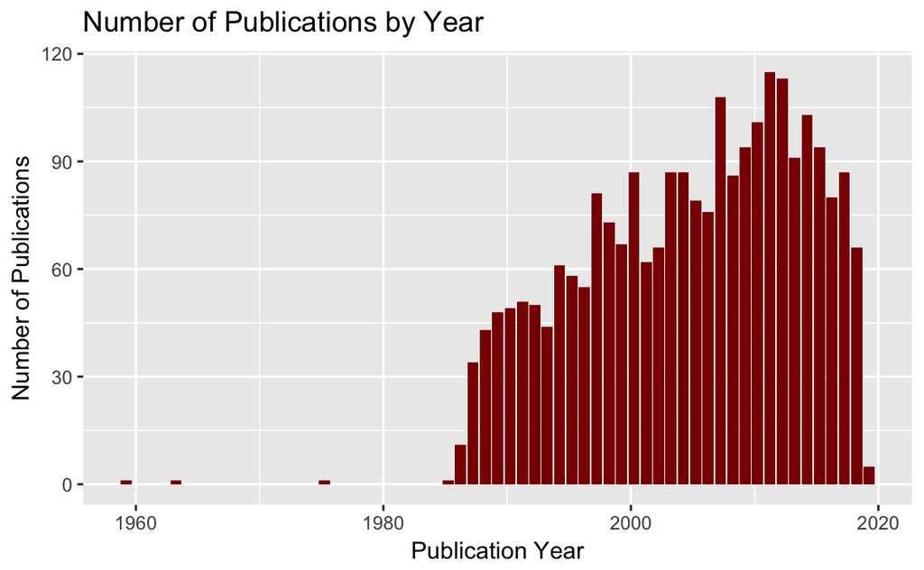

```r
#plot it
pubyear <- group_by(pubdate_all, pubdate)
pubyear.s <- dplyr::summarise(pubyear, count = n())
p1 <- ggplot(data=pubyear.s, aes(x=pubdate, y=count)) +
  geom_bar(stat="identity", fill="dark red") +
  labs(title="Number of Publications by Year", x="Publication Year", y="Number of Publications")
p1
```

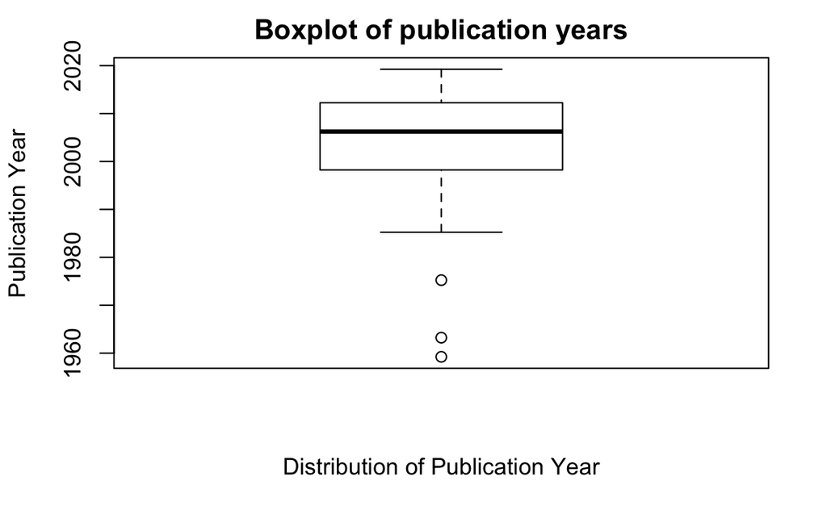

```r
boxplot(pubdate_all$pubdate, main="Boxplot of publication years", xlab = "Distribution of Publication Year", ylab="Publication Year")
```

## Journals Publishing on Castleman Disease

```r
#get all journal titles
journals <- as.data.frame(xpathSApply(castleman,                                      "//PubmedArticle/MedlineCitation/MedlineJournalInfo/MedlineTA",xmlValue), stringsAsFactors = FALSE)
colnames(journals) <- "abbreviated_title"
#group and summarise
journals.g <- group_by(journals, abbreviated_title)
journals.s <- dplyr::summarise(journals.g, count = n())
colnames(journals.s) <- c("Abbreviated Title", "Number of Articles")
#order journals by number of articles
journals.ordered <- journals.s[order(-journals.s$`Number of Articles`),]
#get all countries of the journal
countries <- as.data.frame(xpathSApply(castleman,                                      "//PubmedArticle/MedlineCitation/MedlineJournalInfo/Country",xmlValue), stringsAsFactors = FALSE)
colnames(countries) <- "country"
#unify names to map_world names
countries <- countries %>% mutate(country = if_else(country == "United States", 'USA',
 if_else(country == "United Kingdom", 'UK',
 if_else(country == "China (Republic : 1949- )", "China",
 if_else(country == "England", "UK",
 if_else(country == "Korea (South)", "South Korea",
 if_else(country == "Northern Ireland", "UK",
 if_else(country == "Russia (Federation)", "Russia",
 if_else(country == "Scotland", "UK",
 country)))))))))
#group and summarise
countries.g <- group_by(countries, country)
countries.s <- dplyr::summarise(countries.g, count = n())
colnames(countries.s) <- c("Country of Publication", "Number of Articles")
#order journals by number of articles
countries.ordered <- countries.s[order(-countries.s$`Number of Articles`),]
```

**Which journals are publishing on Castleman Disease?**

We can use the MEDLINE data to identify the journals that are publishing on Castleman Disease. There are 827 different journals publishing on Castleman Disease. The top 25 journals, by number of articles published on Castleman Disease, are shown below:

| Abbreviated Title | Number of Articles |
| --- | --- |
| Blood | 50 |
| Ann Hematol | 33 |
| Intern Med | 33 |
| Am J Hematol | 30 |
| Br J Haematol | 26 |
| Am J Surg Pathol | 25 |
| Histopathology | 23 |
| Leuk Lymphoma | 18 |
| Rinsho Ketsueki | 18 |
| Clin Imaging | 17 |

[output cut: 15 more lines]

These journals are from 58 different countries. The top 25 countires, by number of articles published on Castleman Disease, are shown below:

| Country of Publication | Number of Articles |
| --- | --- |
| USA | 818 |
| UK | 426 |
| Japan | 217 |
| Germany | 170 |
| Spain | 101 |
| France | 94 |
| China | 85 |
| Italy | 72 |
| Netherlands | 60 |
| Switzerland | 56 |

[output cut: 15 more lines]

We can also view the countries of publication on a world map:

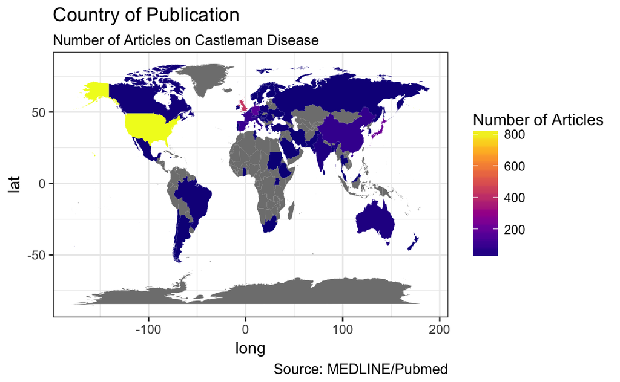

```r
#using ggplot and map_data
#code modified from brennonborbon (2017)
#get map data
map.world <- map_data('world')
#join journal countires with world map data
d <- left_join(map.world, countries.s, by = c('region' = 'Country of Publication'))
#plot it
p2 <- ggplot(data = d, aes(x = long, y = lat, group = group)) +
 geom_polygon(aes(fill = `Number of Articles`)) +
scale_fill_viridis(option = 'plasma')+
labs(title = "Country of Publication", subtitle = "Number of Articles on Castleman Disease", caption = "Source: MEDLINE/Pubmed") +
theme_bw()
p2
```

## Who is Doing the Research?

### Authors

```r
#function to put specific elements into dataframe with PMID
author_df <- function(pmid.value){
  PMID <- xpathSApply(castleman, paste('//PubmedArticle/MedlineCitation[PMID=',pmid.value,']/PMID'), xmlValue)

  if(length(xpathSApply(castleman, paste('//PubmedArticle/MedlineCitation[PMID=',pmid.value,']/Article/AuthorList/Author'), xmlValue)) > 0){
    author <- xpathSApply(castleman, paste('//PubmedArticle/MedlineCitation[PMID=',pmid.value,']/Article/AuthorList/Author'), xmlValue)
  }else{
    author <- 'no author provided'
  }
  as.data.frame(cbind(PMID=PMID, author=author))
}
#loop through this function with a list of PMIDs
data.list <- lapply(pmid_list, author_df)
authors <- as.data.frame(do.call("rbind", data.list), stringsAsFactors = FALSE)
author.g <- group_by(authors, author)
author.s <- dplyr::summarise(author.g, count = n())
author.o <- author.s[order(-author.s$count),]
```

**Who is publishing on Castleman Disease?**

There are 11753 people publishing on Castleman Disease. The top 25 authors, by number of articles published on Castleman Disease, are shown below:

| author | count |
| --- | --- |
| NakamuraShigeoS | 13 |
| BowerMarkM | 11 |
| MasawaNobuhideN | 11 |
| YarchoanRobertR | 10 |
| DieboldJJ | 10 |
| no author provided | 9 |
| StebbingJustinJ | 9 |
| NelsonMarkM | 8 |
| KojimaMasaruM | 8 |
| OksenhendlerEricE | 8 |

[output cut: 15 more lines]

The difficulty here is one of disambiguation. In this list, the author affiliation is concatenated with the author name and our data may be too granular (people change affiliations or no affiliation is reported in MEDLINE for a specific article).

```r
author_df2 <- function(pmid.value){
  PMID <- pmid.value

  if(length(xpathSApply(castleman, paste('//PubmedArticle/MedlineCitation[PMID=',pmid.value,']/Article/AuthorList/Author/LastName'), xmlValue)) > 0){
    lastName <- xpathSApply(castleman, paste('//PubmedArticle/MedlineCitation[PMID=',pmid.value,']/Article/AuthorList/Author/LastName'), xmlValue)
  }else{
    lastName <- 'no name provided'
  }

  if(length(xpathSApply(castleman, paste('//PubmedArticle/MedlineCitation[PMID=',pmid.value,']/Article/AuthorList/Author/Initials'), xmlValue)) > 0){
    initials <- xpathSApply(castleman, paste('//PubmedArticle/MedlineCitation[PMID=',pmid.value,']/Article/AuthorList/Author/Initials'), xmlValue)
  }else{
    initials <- 'no name provided'
  }

  if(length(xpathSApply(castleman, paste('//PubmedArticle/MedlineCitation[PMID=',pmid.value,']/Article/AuthorList/Author/ForeName'), xmlValue)) > 0){
    foreName <- xpathSApply(castleman, paste('//PubmedArticle/MedlineCitation[PMID=',pmid.value,']/Article/AuthorList/Author/ForeName'), xmlValue)
  }else{
    foreName <- 'no name provided'
  }


  as.data.frame(cbind(PMID=PMID, lastName=lastName, foreName=foreName, initials=initials))
}
#loop through this function with a list of PMIDs
data.list <- lapply(pmid_list, author_df2)
authors2 <- as.data.frame(do.call("rbind", data.list), stringsAsFactors = FALSE)
authors2$concatName <- paste(authors2$foreName,
                              authors2$initials,
                              authors2$lastName,
                              sep = " ")
author.g2 <- group_by(authors2, concatName)
author.s2 <- dplyr::summarise(author.g2, count = n())
author.o2 <- author.s2[order(-author.s2$count),]
```

We can try again by stripping out affiliation and only using the concatenation of first name, initials, last name as the representation of a unique author.

| concatName | count |
| --- | --- |
| Masaru M Kojima | 24 |
| Mark M Bower | 20 |
| Corey C Casper | 15 |
| Frits F van Rhee | 15 |
| Norihiro N Nishimoto | 15 |
| Robert R Yarchoan | 15 |
| Angela A Dispenzieri | 14 |
| David C DC Fajgenbaum | 14 |
| Eric E Oksenhendler | 14 |
| Shigeo S Nakamura | 14 |

[output cut: 15 more lines]

### Who is publishing with whom?

**Which authors publish together?**

```r
topAuthors2 <- subset(authors2, authors2$concatName %in% author.o2[1:25,]$concatName)
simpleNetwork(topAuthors2, zoom = TRUE, opacity = 1)
```

[output not shown]

### Affiliations

```r
#function to put specific elements into dataframe with PMID
affiliation_df <- function(pmid.value){
  PMID <- xpathSApply(castleman, paste('//PubmedArticle/MedlineCitation[PMID=',pmid.value,']/PMID'), xmlValue)

  if(length(xpathSApply(castleman, paste('//PubmedArticle/MedlineCitation[PMID=',pmid.value,']/Article/AuthorList/Author/AffiliationInfo/Affiliation'), xmlValue)) > 0){
    affiliation <- xpathSApply(castleman, paste('//PubmedArticle/MedlineCitation[PMID=',pmid.value,']/Article/AuthorList/Author/AffiliationInfo/Affiliation'), xmlValue)
  }else{
    affiliation <- 'no affiliation provided'
  }
  as.data.frame(cbind(PMID=PMID, affiliation=affiliation))
}
#loop through this function with a list of PMIDs
data.list <- lapply(pmid_list, affiliation_df)
affiliations <- as.data.frame(do.call("rbind", data.list), stringsAsFactors = FALSE)
affiliation.g <- group_by(affiliations, affiliation)
affiliation.s <- dplyr::summarise(affiliation.g, count = n())
affiliation.o <- affiliation.s[order(-affiliation.s$count),]
#head(affiliation.o, 10)
```

**What is the institution affiliation of authors?**

There are 2810 institutions publishing on Castleman Disease. The top 25 instituions, by number of articles published on Castleman Disease, are shown below:

| affiliation | count |
| --- | --- |
| no affiliation provided | 367 |
| Nephrology Center, Toranomon Hospital, 2-2-2, Toranomon, Minato, Tokyo, 105-8470, Japan. | 15 |
| Division of Infectious Diseases and Pulmonary Medicine, Department of Internal Medicine, National Defense Medical College, Saitama, Japan. | 12 |
| UNC Project-Malawi, Lilongwe, Malawi. | 10 |
| Department of Haematology, Peking University First Hospital, Beijing, China. | 10 |
| Henan Key Lab of Experimental Haematology, Henan Institute of Haematology, Henan Cancer Hospital affiliated to Zhengzhou University, Zhengzhou, China. | 10 |
| Department of Cardiology, Keio University School of Medicine, Japan. | 10 |
| Department of Hematology and Immunology, Kanazawa Medical University. | 9 |
| Haematopathology Unit, Department of Experimental, Diagnostic and Specialty Medicine (DIMES), S. Orsola-Malpighi Hospital, Bologna University School of Medicine, Bologna, Italy. | 9 |
| Hematology Research Center, Ministry of Health of Russia, Moscow, Russia. | 9 |

[output cut: 15 more lines]

```r
topAffiliations <- subset(affiliations, affiliations$affiliation %in% affiliation.o[2:101,]$affiliation)
simpleNetwork(topAffiliations, zoom = TRUE, opacity = 1)
```

## What Research is Getting Funded?

```r
#get all grant agencies
agencies <- as.data.frame(xpathSApply(castleman,                                      "//PubmedArticle/MedlineCitation/Article/GrantList/Grant/Agency", xmlValue), stringsAsFactors = FALSE)
colnames(agencies) <- "agency"
#group and summarise
agencies.g <- group_by(agencies, agency)
agencies.s <- dplyr::summarise(agencies.g, count = n())
#top 10 agencies funding research (by count, not $$$)
agencies.o <- agencies.s[order(-agencies.s$count),]
#get all countries of the granting agencies
countries.ag <- as.data.frame(xpathSApply(castleman,                                      "//PubmedArticle/MedlineCitation/Article/GrantList/Grant/Country",xmlValue), stringsAsFactors = FALSE)
colnames(countries.ag) <- "country"
#group and summarise
countriesag.g <- group_by(countries.ag, country)
countriesag.s <- dplyr::summarise(countriesag.g, count = n())
#top 10 countries of publication
countriesag.o <- countriesag.s[order(-countriesag.s$count),]
#head(countriesag.ordered[1:10,])
```

There are 25 difference agencies funding research on Castleman Disease. The top 25 agencies, by number of articles funded on Castleman Disease, are shown below:

| agency | count |
| --- | --- |
| NCI NIH HHS | 136 |
| NIAID NIH HHS | 37 |
| Intramural NIH HHS | 16 |
| NCRR NIH HHS | 16 |
| NHLBI NIH HHS | 9 |
| PHS HHS | 9 |
| NIDCR NIH HHS | 7 |
| CCR NIH HHS | 6 |
| FIC NIH HHS | 6 |
| NIGMS NIH HHS | 6 |

[output cut: 15 more lines]

These agencies are from 3 different countries. The top 5 countries, by number of articles funded on Castleman Disease, are shown below:

| country | count |
| --- | --- |
| United States | 264 |
|  | 4 |
| United Kingdom | 3 |

# Open Access Licenses

```r
#this code chunk was run once to pull OA data from CrossRef APIs

#Get DOI for each article
dois <- as.data.frame(xpathSApply(castleman, '//PubmedArticle/PubmedData/ArticleIdList/ArticleId[@IdType="doi"]', xmlValue), stringsAsFactors = FALSE)
colnames(dois) <- "doi"

#remove malformed dois
dois <- subset(dois, dois$doi != "/S0716-10182011000100015")
dois <- subset(dois, dois$doi != "1.2006/JCPSP.7475")

#Function to call CrossRef and oaDOI APIs -----

getOA <- function(x){
  #build CrossRef API URL from function input
  cr.url <- paste("https://api.crossref.org/works?filter=doi:", x, sep = "")

  #get CrossRef work data
  cr <- fromJSON(file = cr.url)

  #extract license data

  if(length(cr[["message"]] [["items"]]) >0){

      cr.url <- ifelse(length(cr[["message"]] [["items"]] [[1]] [["license"]]) >0,
                       cr[["message"]] [["items"]] [[1]] [["license"]] [[1]] [["URL"]],
                       "No license information provided")
      cr.urlalt <- ifelse(length(cr[["message"]] [["items"]] [[1]] [["license"]]) >1,
                          cr[["message"]] [["items"]] [[1]] [["license"]] [[2]] [["URL"]],
                          "No alternative URL provided")

    } else {
      #build variables for non-existent DOIs
      cr.url <- "Data not found"
      cr.urlalt <- "Data not found"

    }


  #put the information together
  data.final <- as.data.frame(cbind(x, cr.url, cr.urlalt))

  data.final
}

#create list of DOIs to query ----
temp <- dois[751:1153,]
mylist <- as.list(temp)

#apply function to list; assemble into dataframe
Sys.time()
data.list <- lapply(mylist, getOA)
final <- as.data.frame(do.call("rbind", data.list), stringsAsFactors = FALSE)
Sys.time()

oa.1153 <- final
oa.500 <- read_csv("oa_1_500.csv", col_names = TRUE)
oa.500 <- oa.500[,-1]

oa.all <- rbind(oa.500, oa.750, oa.1153)

#the above function was used to call the CrossRef API to get OA license information. After doing this once, the results were saved to a .CSV file that could be loaded at later times to save time
write.csv(oa.all, "oa_All.csv")

oa.All.g <- group_by(oa.all, cr.url)
oa.All.s <- dplyr::summarise(oa.All.g, count = n())

#top 10 licenses attributed to publications
oa.All.o <- oa.All.s[order(-oa.All.s$count),]
```

```r
#this code uses the results of the OA function saved to a csv file
oa.all <- read_csv("oa_All.csv", col_names = TRUE)
oa.all <- oa.all[,-1]
oa.All.g <- group_by(oa.all, cr.url)
oa.All.s <- dplyr::summarise(oa.All.g, count = n())

#top licenses attributed to publications
oa.All.o <- oa.All.s[order(-oa.All.s$count),]
```

There are 21 different licenses attributed to Castleman Disease articles. The top licenses, by number of articles, are shown below:

| cr.url | count |
| --- | --- |
| No license information provided | 556 |
| https://www.elsevier.com/tdm/userlicense/1.0/ | 231 |
| http://doi.wiley.com/10.1002/tdm_license_1.1 | 160 |
| http://www.springer.com/tdm | 56 |
| Data not found | 42 |
| http://journals.sagepub.com/page/policies/text-and-data-mining-license | 31 |
| https://www.karger.com/Services/SiteLicenses | 20 |
| http://www.elsevier.com/tdm/userlicense/1.0/ | 17 |
| http://doi.wiley.com/10.1002/tdm_license_1 | 7 |
| http://creativecommons.org/licenses/by-nc/3.0 | 5 |

[output cut: 11 more lines]

# Exploring Relationships in the Literature

## Most-Cited Articles

```r
#function to get PMID and cited PMID
citation_df <- function(pmid.value){
  #get main PMID
  PMID <- xpathSApply(castleman, paste('//PubmedArticle/MedlineCitation[PMID=',pmid.value,']/PMID'), xmlValue)

  #get referenceIDs
  if(length(xpathSApply(castleman, paste('//PubmedArticle[MedlineCitation/PMID=',pmid.value,']/PubmedData/ReferenceList/Reference/ArticleIdList/ArticleId[@IdType="pubmed"]'), xmlValue)) > 0){
    referenceID <- xpathSApply(castleman, paste('//PubmedArticle[MedlineCitation/PMID=',pmid.value,']/PubmedData/ReferenceList/Reference/ArticleIdList/ArticleId[@IdType="pubmed"]'), xmlValue)
  } else {
    referenceID <- 'no cited reference'
  }
  #put together into a dataframe
  as.data.frame(cbind(PMID=PMID, referenceID=referenceID))
}
#apply function to list
data.list <- lapply(pmid_list, citation_df)
final <- as.data.frame(do.call("rbind", Filter(function(x) length(x)==2, data.list)), stringsAsFactors = FALSE)
#drop no cited reference
final.final <- subset(final, final$referenceID != "no cited reference")
final.final$PMID <- as.character(final.final$PMID)
final.final$referenceID <- as.character(final.final$referenceID)
#identify most cited PMIDs
final.g <- group_by(final.final, referenceID)
final.s <- dplyr::summarise(final.g, count=n())
final.o <- final.s[order(final.s$count, decreasing = TRUE),]
top5 <- as.character(as.list(final.o[1:5,]$referenceID))
top10 <- as.character(as.list(final.o[1:10,]$referenceID))
top25 <- as.character(as.list(final.o[1:25,]$referenceID))
top5.cited <- subset(final.final, final.final$referenceID %in% top5)
top10.cited <- subset(final.final, final.final$referenceID %in% top10)
k=25
inCorpus = matrix(0, nrow = k, ncol = 1, byrow = TRUE)
for (i in 1:k){
inCorpus[i,1] = top25[[i]] %in% pmid_list
}
k=nrow(final.s)
inCorpusAll = matrix(0, nrow = k, ncol = 1, byrow = TRUE)
for (i in 1:k){
inCorpusAll[i,1] = final.s[i,]$referenceID %in% pmid_list
}
```

**What are the most influential articles for Castleman Disease?**

The top cited articles are:

13356266, 4551306, 2788466, 7632932, 15998837, 10091744, 4031967, 7997879, 11505414, 619617, 10607684, 8302342, 9537940, 15801951, 2384605, 7700311, 8924253, 24622327, 2579015, 10666218, 15764213, 19546611, 2464187, 8296200, 10979949

The number of most influential articles not in the core corpus is 7

The core corpus cites 3320 articles outside the core corpus.

## Citation Graph

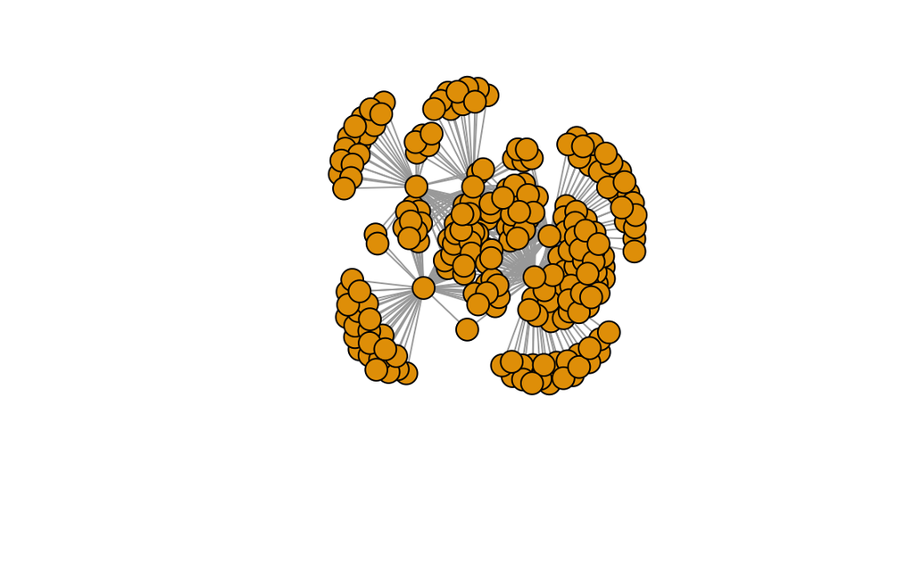

```r
g5 <- graph_from_data_frame(top5.cited, directed=FALSE)
plot(g5,
     vertex.label=NA)
```

**When were the most cited publications published?**

```r
#plot the publication year of the most cited research
pubdates.df <- function(pmid.value){
  #get main PMID
  PMID <- xpathSApply(castleman, paste('//PubmedArticle/MedlineCitation[PMID=',pmid.value,']/PMID'), xmlValue)

  pubdate <- xpathSApply(castleman, paste('//PubmedArticle[MedlineCitation/PMID=',pmid.value,']/MedlineCitation/Article/Journal/JournalIssue/PubDate/Year'), xmlValue)

  as.data.frame(cbind(PMID=PMID, pubdate=pubdate))
}

top100 <- as.character(as.list(final.o[1:100,]$referenceID))
data.list2 <- lapply(top100, pubdates.df)
dates <- as.data.frame(do.call("rbind", Filter(function(x) length(x)==2, data.list2)), stringsAsFactors = FALSE)
dates.g <- group_by(dates, pubdate)
dates.s <- dplyr::summarise(dates.g, count=n())
dates.s$pubdate <- as.Date(dates.s$pubdate, format = "%Y")

p1 <- ggplot(data=dates.s, aes(x=pubdate, y=count)) +
  geom_bar(stat="identity", fill="dark red") +
  labs(title="Number of Publications by Year")
p1
```

[output not shown]

# Topics and Concepts

## Unsupervised learning of topics

```r
#get our abstract
abstract_all <- as.data.frame(xpathSApply(castleman, "//Abstract", xmlValue), stringsAsFactors = FALSE)
colnames(abstract_all) <- "abstract"
abstract_all <- subset(abstract_all, abstract_all$abstract != "") #remove blank abstracts

#create a corpus
source <- VectorSource(abstract_all$abstract)
corpus <- Corpus(source)

#clean up the corpus
corpus <- tm_map(corpus, content_transformer(tolower))
#corpus <- tm_map(corpus, removeNumbers) #choosing not to do this in order to preserve numbers in chemical names
corpus <- tm_map(corpus, removePunctuation)
corpus <- tm_map(corpus, stripWhitespace)
corpus <- tm_map(corpus, removeWords, stopwords('english'))

#create document-term matrix
DTM <- DocumentTermMatrix(corpus)

#remove infrequent words
freq_words <- findFreqTerms(DTM, 5)
DTM <- DTM[,freq_words]

#create unique indexes; this step prevents us from getting errors
unique_indexes <- unique(DTM$i)
DTM <- DTM[unique_indexes,]
```

# Finding optimal topics

```r
#LDA tuning, Gibbs method
Sys.time()
```

```
[1] "2019-03-24 07:59:06 EDT"
```

```r
result.g <- FindTopicsNumber(
  DTM,
  topics = seq(from = 10, to = 100, by = 10),
  metrics = c("Griffiths2004", "CaoJuan2009", "Arun2010", "Deveaud2014"),
  method = "Gibbs",
  control = list(burnin = 1000, iter = 1000, keep = 50),
  mc.cores = 3L, #change this to match the cores on your machine
  verbose = TRUE
)
```

```
fit models... done.
calculate metrics:
  Griffiths2004... done.
  CaoJuan2009... done.
  Arun2010... done.
  Deveaud2014... done.
```

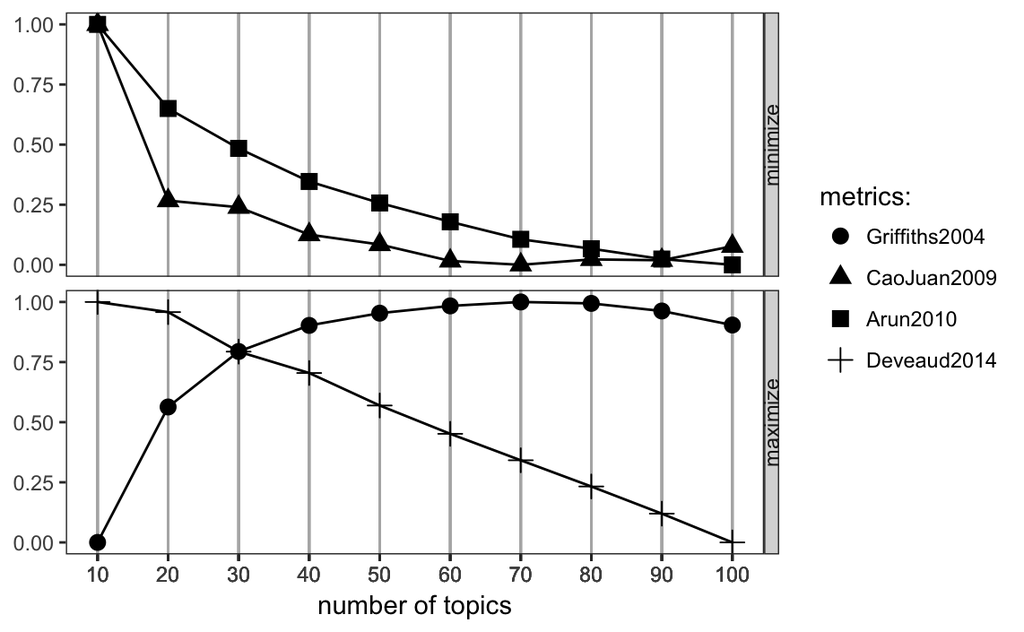

```r
FindTopicsNumber_plot(result.g)
```

```r
Sys.time()
```

```
[1] "2019-03-24 08:05:07 EDT"
```

# topic modeling

```r
#get our abstract
abstract_all <- as.data.frame(xpathSApply(castleman, "//Abstract", xmlValue), stringsAsFactors = FALSE)
colnames(abstract_all) <- "abstract"
abstract_all <- subset(abstract_all, abstract_all$abstract != "") #remove blank abstracts
#create a corpus
source <- VectorSource(abstract_all$abstract)
corpus <- Corpus(source)
#clean up the corpus
corpus <- tm_map(corpus, content_transformer(tolower))
#corpus <- tm_map(corpus, removeNumbers) #choosing not to do this in order to preserve numbers in chemical names
corpus <- tm_map(corpus, removePunctuation)
corpus <- tm_map(corpus, stripWhitespace)
corpus <- tm_map(corpus, removeWords, stopwords('english'))
#create document-term matrix
DTM <- DocumentTermMatrix(corpus)
#remove infrequent words
freq_words <- findFreqTerms(DTM, 5)
DTM <- DTM[,freq_words]
#create unique indexes; this step prevents us from getting errors
unique_indexes <- unique(DTM$i)
DTM <- DTM[unique_indexes,]
```

The topics discussed in this corpus of ariticles are:

cells, disease, lymphoid, may, patients, serum, compared, rights, vascular, disease, hhv8, patient, pemphigus, therapy, localized, systemic, chest, tumor, antibody, syndrome, cells, treatment, disorder, disease, disease, biopsy, cells, diseases, showed, clinical, il6, case, lymph, kshv, cell, one, detected, renal, diagnosis, mcd, mass, lymphoma, cases, unicentric, anemia

# Text Summarization

```r
#uses 'textmineR' library
#get PMID and abstracts
abstracts_df <- function(pmid.value){
  #get main article PMID
  PMID <- xpathSApply(castleman, paste('//PubmedArticle/MedlineCitation[PMID=',pmid.value,']/PMID'), xmlValue)

  #get abstract if present
  if(length(xpathSApply(castleman, paste('//PubmedArticle/MedlineCitation[PMID=',pmid.value,']/Article/Abstract'), xmlValue)) > 0){
    abstract <- xpathSApply(castleman, paste('//PubmedArticle/MedlineCitation[PMID=',pmid.value,']/Article/Abstract'), xmlValue)
  }else{
    abstract <- 'no abstract provided'
  }
  as.data.frame(cbind(PMID=PMID, abstract=abstract))
}
#loop through this function with a list of PMIDs
data.list <- lapply(pmid_list, abstracts_df)
final.abs <- as.data.frame(do.call("rbind", data.list), stringsAsFactors = FALSE)
#drop blank abstracts
abstracts <- subset(final.abs, !(final.abs$abstract == "") & !(final.abs$abstract == "no abstract provided"))
#code modified from Jones (Document Summarization, 2019)
#create a TCM using skim grams with 5-word window
tcm <- CreateTcm(doc_vec = abstracts$abstract,
                 skipgram_window = 10,
                 verbose = FALSE,
                 cpus = 3)
#use LDA to get embeddings into probability space
embeddings <- FitLdaModel(dtm = tcm,
                          k = 50,
                          iterations = 200,
                          burnin = 180,
                          alpha = 0.1,
                          beta = 0.05,
                          optimize_alpha = TRUE,
                          calc_likelihood = FALSE,
                          calc_coherence = TRUE,
                          calc_r2 = TRUE)
#time for summarization
summarizer <- function(doc, gamma) {

  # recurse through multiple documents
  if (length(doc) > 1 )
    # use a try statement to catch errors
    return(sapply(doc, function(d) try(summarizer(d, gamma))))

  # parse it into sentences
  sent <- stringi::stri_split_boundaries(doc, type = "sentence")[[ 1 ]]

  names(sent) <- seq_along(sent) # so we know index and order

  # embed the sentences in the model
  e <- CreateDtm(sent, ngram_window = c(1,1), verbose = FALSE, cpus = 2)

  # remove any documents with 2 or fewer words
  e <- e[ rowSums(e) > 2 , ]

  vocab <- intersect(colnames(e), colnames(gamma))

  e <- e / rowSums(e)

  e <- e[ , vocab ] %*% t(gamma[ , vocab ])

  e <- as.matrix(e)

  # get the pairwise distances between each embedded sentence
  e_dist <- CalcHellingerDist(e)

  # turn into a similarity matrix
  g <- (1 - e_dist) * 100

  # we don't need sentences connected to themselves
  diag(g) <- 0

  # turn into a nearest-neighbor graph
  g <- apply(g, 1, function(x){
    x[ x < sort(x, decreasing = TRUE)[ 3 ] ] <- 0
    x
  })

  # by taking pointwise max, we'll make the matrix symmetric again
  g <- pmax(g, t(g))

  g <- graph.adjacency(g, mode = "undirected", weighted = TRUE)

  # calculate eigenvector centrality
  ev <- evcent(g)

  # format the result
  result <- sent[ names(ev$vector)[ order(ev$vector, decreasing = TRUE)[ 1:2 ] ] ]

  result <- result[ order(as.numeric(names(result))) ]

  paste(result, collapse = " ")
}
#get summaries for select abstracts
docs <- abstracts$abstract[10:15] #selecting arbitrary abstracts to summarize
names(docs) <- abstracts$PMID[10:15]
sums <- summarizer(docs, gamma = embeddings$gamma)
topDocs2 <- subset(abstracts, abstracts$PMID == "2788466")
docs2 <- topDocs2$abstract
sums2 <- summarizer(docs2, gamma = embeddings$gamma)
topDocs3 <- subset(abstracts, abstracts$PMID == "7632932")
docs3 <- topDocs3$abstract
sums3 <- summarizer(docs3, gamma = embeddings$gamma)
topDocs4 <- subset(abstracts, abstracts$PMID == "15998837")
docs4 <- topDocs4$abstract
sums4 <- summarizer(docs4, gamma = embeddings$gamma)
```

In a patient with a solitary hyperplastic lymph node, clinical improvement and decrease in serum IL-6 were observed following surgical removal of the involved lymph node. The findings in this report indicate that the generation of IL-6 by B cells in germinal centers of hyperplastic lymph nodes of Castleman’s disease may be the key element responsible for the variety of clinical symptoms in this disease.

KSHV sequences were detected in 14 of 14 cases of HIV-associated MCD, including 5 cases without detectable KS. Moreover, KSHV was detected in 7 of 17 MCD cases in HIV-negative patients, including 1 case associated with a cutaneous KS.

Within 16 weeks, treatment with MRA consistently alleviated lymphadenopathy and all the inflammatory parameters. MRA was tolerated well and significantly alleviated chronic inflammatory symptoms and wasting in patients with MCD.

# Document Clustering

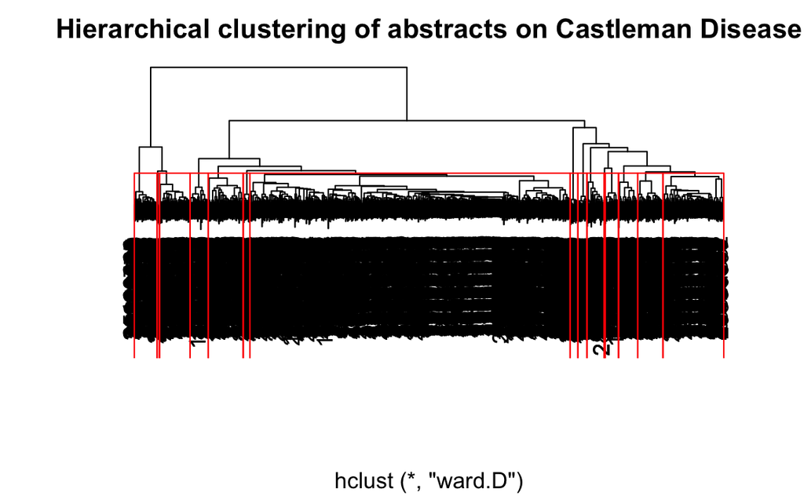

```r
#Code modified from Jones (Document Clustering, 2019)
# create a document term matrix
dtm <- CreateDtm(doc_vec = abstracts$abstract,
                 doc_names = abstracts$PMID,
                 ngram_window = c(1, 2), # minimum and maximum n-gram length
                 stopword_vec = c(stopwords::stopwords("en"),
                                  stopwords::stopwords(source = "smart")),
                 lower = TRUE,
                 remove_punctuation = TRUE,
                 remove_numbers = FALSE, #remaining consistent with choice made in LDA
                 verbose = FALSE,
                 cpus = 3)
# construct the matrix of term counts to get the IDF vector
tf_mat <- TermDocFreq(dtm)
# TF-IDF and cosine similarity
tfidf <- t(dtm[ , tf_mat$term ]) * tf_mat$idf
tfidf <- t(tfidf)
csim <- tfidf / sqrt(rowSums(tfidf * tfidf))
csim <- csim %*% t(csim)
cdist <- as.dist(1 - csim)
#cluster the documents
hc <- hclust(cdist, "ward.D")
clustering <- cutree(hc, 15)
plot(hc, main = "Hierarchical clustering of abstracts on Castleman Disease",
     ylab = "", xlab = "", yaxt = "n")
rect.hclust(hc, 15, border = "red")
```

```r
#What's in it?
p_words <- colSums(dtm) / sum(dtm)
cluster_words <- lapply(unique(clustering), function(x){
  rows <- dtm[ clustering == x , ]

  # Drop all words that don't appear in the cluster
  rows <- rows[ , colSums(rows) > 0 ]

  colSums(rows) / sum(rows) - p_words[ colnames(rows) ]
})
# create a summary table of the top 5 words defining each cluster
cluster_summary <- data.frame(cluster = unique(clustering),
                              size = as.numeric(table(clustering)),
                              top_words = sapply(cluster_words, function(d){
                                paste(
                                  names(d)[ order(d, decreasing = TRUE) ][ 1:5 ],
                                  collapse = ", ")
                              }),
                              stringsAsFactors = FALSE)
cluster_summary
```

```
   cluster size
1        1  952
2        2  181
3        3   20
4        4   91
5        5   40
6        6   27
7        7   75
8        8   57
9        9   54
10      10   68
11      11   51
12      12  104
13      13    3
14      14   23
```

[output cut: 17 more lines]

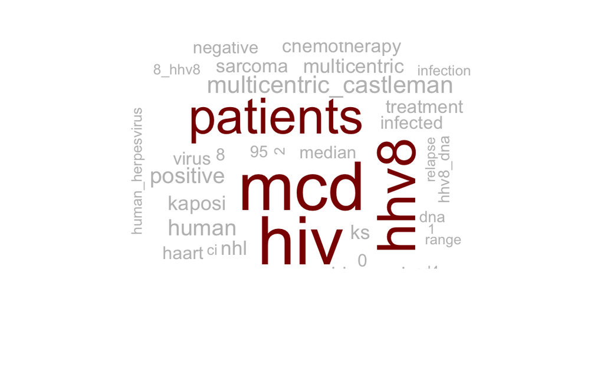

```r
# plot a word cloud of one cluster as an example
wordcloud::wordcloud(words = names(cluster_words[[ 7 ]]),
                     freq = cluster_words[[ 7 ]],
                     max.words = 50,
                     random.order = FALSE,
                     colors = c("grey", "dark blue", "dark red"),
                     main = "Top words in cluster 100")
```

```r
#finding optimal number for k
#Code modified from Gyrgorian (2017)
# Finding the optimal number of clusters using Dunn Index
k = 50
mat = matrix(0, nrow = k, ncol = 2, byrow = TRUE)
for (i in 1:k) {
  members = cutree(hc, i)
  dunn_index = dunn(clusters = members, Data = cdist)
  mat[i,1] = i
  mat[i,2] = dunn_index
}
```

```
no non-missing arguments to min; returning Inf
```

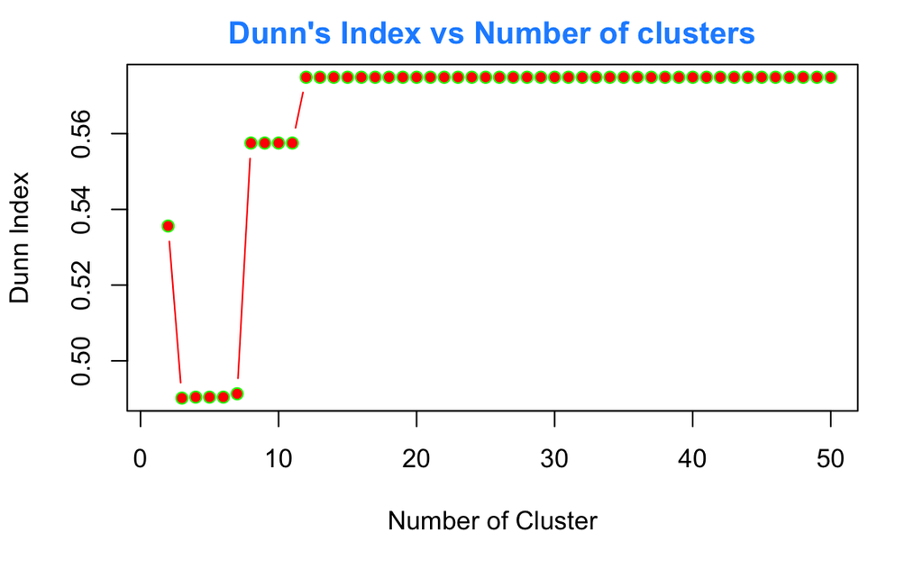

```r
# Plot number of clusters vs Dunn Index
plot(mat,
     type = 'b',
     xlab = "Number of Cluster",
     ylab = "Dunn Index",
     pch = 16,
     col = "red",
     main = "Dunn's Index vs Number of clusters",
     col.main = "dodgerblue")
points(mat, col = "green")
```

## LDA and LSA

```r
#using the dtm created above
#code modified from Jones (Topic Modeling, 2019)
set.seed(12345)
model <- FitLdaModel(dtm = dtm,
                     k = 45,
                     iterations = 500,
                     burnin = 180,
                     alpha = 0.1,
                     beta = 0.05,
                     optimize_alpha = TRUE,
                     calc_likelihood = TRUE,
                     calc_coherence = TRUE,
                     calc_r2 = TRUE,
                     cpus = 3)
str(model)
```

```
List of 9
 $ phi           : num [1:45, 1:100840] 7.02e-06 5.48e-06 4.15e-06 7.19e-06 5.01e-06 ...
  ..- attr(*, "dimnames")=List of 2
  .. ..$ : chr [1:45] "t_1" "t_2" "t_3" "t_4" ...
  .. ..$ : chr [1:100840] "mildest_neuropathy" "biopsies_blood" "cases_finding" "tumors_describe" ...
 $ theta         : num [1:1753, 1:45] 0.000391 0.000264 0.000858 0.000297 0.00066 ...
  ..- attr(*, "dimnames")=List of 2
  .. ..$ : chr [1:1753] "30586033" "30504327" "30516666" "30455306" ...
  .. ..$ : chr [1:45] "t_1" "t_2" "t_3" "t_4" ...
 $ gamma         : num [1:45, 1:100840] 0.0205 0.0227 0.0253 0.0202 0.0234 ...
  ..- attr(*, "dimnames")=List of 2
  .. ..$ : chr [1:45] "t_1" "t_2" "t_3" "t_4" ...
  .. ..$ : chr [1:100840] "mildest_neuropathy" "biopsies_blood" "cases_finding" "tumors_describe" ...
 $ data          :Formal class 'dgCMatrix' [package "Matrix"] with 6 slots
  .. ..@ i       : int [1:265913] 115 79 814 766 258 1336 1703 400 245 1343 ...
  .. ..@ p       : int [1:100841] 0 1 2 3 4 5 6 7 8 9 ...
  .. ..@ Dim     : int [1:2] 1753 100840
  .. ..@ Dimnames:List of 2
  .. .. ..$ : chr [1:1753] "30586033" "30504327" "30516666" "30455306" ...
  .. .. ..$ : chr [1:100840] "mildest_neuropathy" "biopsies_blood" "cases_finding" "tumors_describe" ...
  .. ..@ x       : num [1:265913] 1 1 1 1 1 1 1 1 1 1 ...
  .. ..@ factors : list()
 $ alpha         : num [1:45] 0.0666 0.0974 0.1414 0.0678 0.1041 ...
 $ beta          : num [1:45, 1:100840] 0.05 0.05 0.05 0.05 0.05 0.05 0.05 0.05 0.05 0.05 ...
 $ log_likelihood:'data.frame': 50 obs. of  2 variables:
  ..$ iteration     : num [1:50] 0 10 20 30 40 50 60 70 80 90 ...
  ..$ log_likelihood: num [1:50] -3900812 -3728813 -3660240 -3633933 -3625338 ...
 $ coherence     : Named num [1:45] 0.139 0.309 0.492 0.079 0.058 ...
  ..- attr(*, "names")= chr [1:45] "t_1" "t_2" "t_3" "t_4" ...
 $ r2            : num 0.195
 - attr(*, "class")= chr "lda_topic_model"
```

```r
model$r2
```

```
[1] 0.195176
```

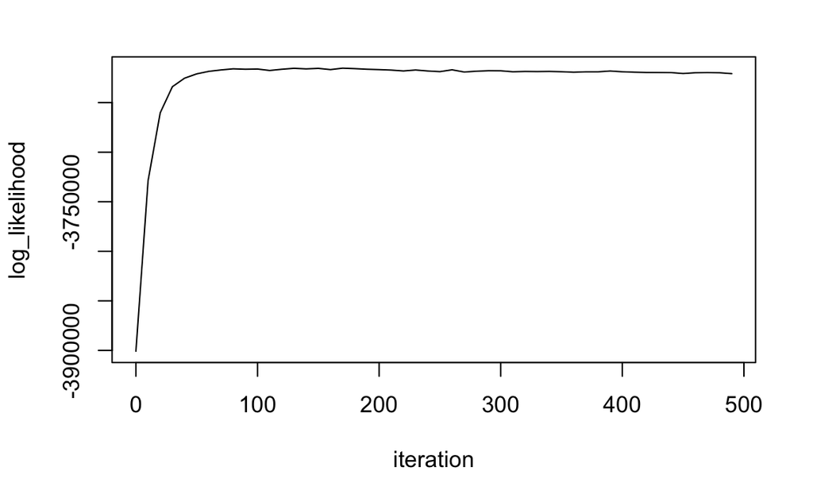

```r
plot(model$log_likelihood, type = "l")
```

```r
summary(model$coherence)
```

```
   Min. 1st Qu.  Median    Mean 3rd Qu.    Max.
0.03345 0.08466 0.18134 0.22749 0.29880 0.75722
```

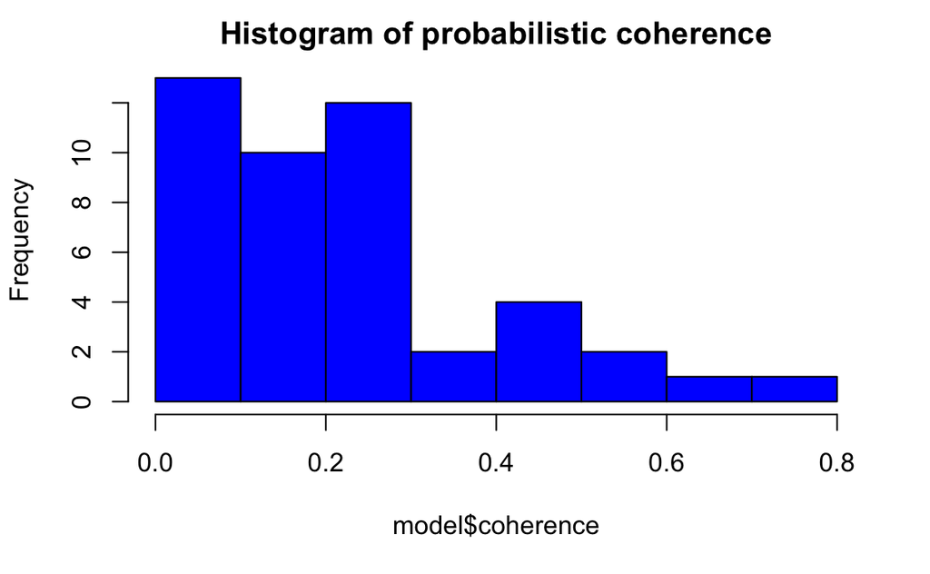

```r
hist(model$coherence,
     col= "blue",
     main = "Histogram of probabilistic coherence")
```

```r
model$top_terms <- GetTopTerms(phi = model$phi, M = 5)
head(t(model$top_terms))
```

```
    [,1]     [,2]             [,3]        [,4]
t_1 "anemia" "sle"            "needle"    "diagnosis"
t_2 "cases"  "chain"          "ebv"       "barr"
t_3 "kaposi" "kaposi_sarcoma" "sarcoma"   "kshv"
t_4 "liver"  "hyperplasia"    "lymphoid"  "case"
t_5 "neck"   "disease"        "diagnosis" "castleman_disease"
t_6 "type"   "plasma"         "cell"      "plasma_cell"
    [,5]
t_1 "fine"
t_2 "epstein"
t_3 "ks"
t_4 "lymphoid_hyperplasia"
t_5 "castleman"
t_6 "disease"
```

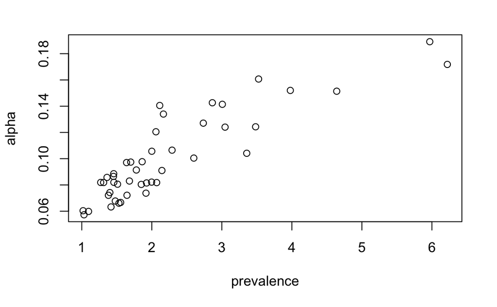

```r
model$prevalence <- colSums(model$theta) / sum(model$theta) * 100
plot(model$prevalence, model$alpha, xlab = "prevalence", ylab = "alpha")
```

```r
model$labels <- LabelTopics(assignments = model$theta > 0.05,
                            dtm = dtm,
                            M = 1)
head(model$labels)
```

```
    label_1
t_1 "fine_needle"
t_2 "hhv_8"
t_3 "kaposi_sarcoma"
t_4 "lymphoid_hyperplasia"
t_5 "castleman_disease"
t_6 "plasma_cell"
```

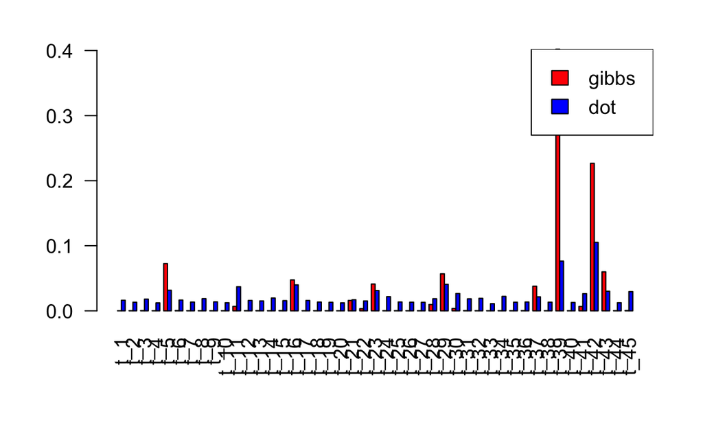

```r
#model$summary[ order(model$summary$prevalence, decreasing = TRUE) , ][ 1:10 , ]
assignments <- predict(model, dtm,
                       method = "gibbs",
                       iterations = 200,
                       burnin = 180,
                       cpus = 2)
assignments_dot <- predict(model, dtm,
                           method = "dot")
barplot(rbind(assignments[10,], assignments_dot[10,]),
        col = c("red", "blue"), las = 2, beside = TRUE)
legend("topright", legend = c("gibbs", "dot"), col = c("red", "blue"),
       fill = c("red", "blue"))
```

```r
#LSA
tf_sample <- TermDocFreq(dtm)
tf_sample$idf[ is.infinite(tf_sample$idf) ] <- 0 # fix idf for missing words
tf_idf <- t(dtm / rowSums(dtm)) * tf_sample$idf
tf_idf <- t(tf_idf)
lsa_model <- FitLsaModel(dtm = tf_idf,
                     k = 45)
str(lsa_model)
```

```
List of 6
 $ sv       : num [1:45] 1.85 1.36 1.15 1.09 1.09 ...
 $ theta    : num [1:1753, 1:45] -0.0268 -0.0224 -0.0257 -0.0177 -0.0215 ...
  ..- attr(*, "dimnames")=List of 2
  .. ..$ : chr [1:1753] "30586033" "30504327" "30516666" "30455306" ...
  .. ..$ : chr [1:45] "t_1" "t_2" "t_3" "t_4" ...
 $ phi      : num [1:45, 1:100840] -2.55e-04 8.50e-06 2.99e-04 -7.18e-05 -9.01e-05 ...
  ..- attr(*, "dimnames")=List of 2
  .. ..$ : chr [1:45] "t_1" "t_2" "t_3" "t_4" ...
  .. ..$ : chr [1:100840] "mildest_neuropathy" "biopsies_blood" "cases_finding" "tumors_describe" ...
 $ gamma    : num [1:45, 1:100840] -1.38e-04 6.24e-06 2.59e-04 -6.58e-05 -8.27e-05 ...
  ..- attr(*, "dimnames")=List of 2
  .. ..$ : chr [1:45] "t_1" "t_2" "t_3" "t_4" ...
  .. ..$ : chr [1:100840] "mildest_neuropathy" "biopsies_blood" "cases_finding" "tumors_describe" ...
 $ coherence: Named num [1:45] 0.999 0.114 0.274 0.289 0.999 ...
  ..- attr(*, "names")= chr [1:45] "t_1" "t_2" "t_3" "t_4" ...
 $ data     :Formal class 'dgCMatrix' [package "Matrix"] with 6 slots
  .. ..@ i       : int [1:265913] 115 79 814 766 258 1336 1703 400 245 1343 ...
  .. ..@ p       : int [1:100841] 0 1 2 3 4 5 6 7 8 9 ...
  .. ..@ Dim     : int [1:2] 1753 100840
  .. ..@ Dimnames:List of 2
  .. .. ..$ : chr [1:1753] "30586033" "30504327" "30516666" "30455306" ...
  .. .. ..$ : chr [1:100840] "mildest_neuropathy" "biopsies_blood" "cases_finding" "tumors_describe" ...
  .. ..@ x       : num [1:265913] 0.0214 0.0326 0.0205 0.0839 0.0295 ...
  .. ..@ factors : list()
 - attr(*, "class")= chr "lsa_topic_model"
```

```r
summary(lsa_model$coherence)
```

```
    Min.  1st Qu.   Median     Mean  3rd Qu.     Max.
0.003196 0.114964 0.249441 0.330177 0.444862 0.999429
```

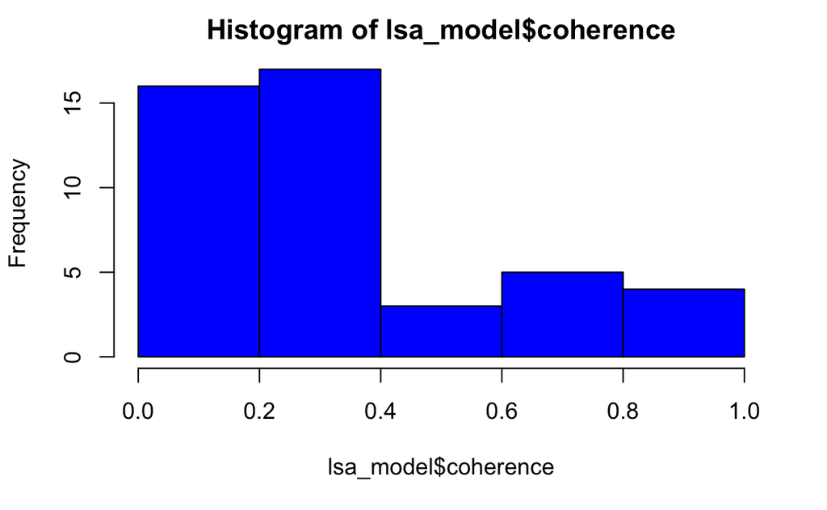

```r
hist(lsa_model$coherence, col= "blue")
```

```r
lsa_model$top_terms <- GetTopTerms(phi = lsa_model$phi, M = 5)
head(t(lsa_model$top_terms))
```

```
    [,1]                [,2]                 [,3]
t_1 "subject_secondary" "intestinal_villous" "urine_chloride"
t_2 "mass"              "retroperitoneal"    "ct"
t_3 "il"                "il_6"               "6"
t_4 "il"                "kshv"               "il_6"
t_5 "lip_10"            "hyperplasia_looked" "case_lymphoid"
t_6 "lymphoma_examined" "clinical_remarks"   "examined_recently"
    [,4]                   [,5]
t_1 "examination_presence" "diet_corrected"
t_2 "tumor"                "vascular_type"
t_3 "tocilizumab"          "igg4"
t_4 "6"                    "hhv"
t_5 "looked_mucocele"      "mucocele_lower"
t_6 "literature_make"      "recently_starting"
```

```r
lsa_model$prevalence <- colSums(lsa_model$theta) / sum(lsa_model$theta) * 100
lsa_model$labels <- LabelTopics(assignments = lsa_model$theta > 0.05,
                            dtm = dtm,
                            M = 1)
head(lsa_model$labels)
```

```
    label_1
t_1 "mildest_neuropathy"
t_2 "giant_lymph"
t_3 "il_6"
t_4 "mildest_neuropathy"
t_5 "lymphoid_hyperplasia"
t_6 "poems_syndrome"
```

```r
lsa_model$summary <- data.frame(topic = rownames(lsa_model$phi),
                            label = lsa_model$labels,
                            coherence = round(lsa_model$coherence, 3),
                            prevalence = round(lsa_model$prevalence,3),
                            top_terms = apply(lsa_model$top_terms, 2, function(x){
                              paste(x, collapse = ", ")
                            }),
                            stringsAsFactors = FALSE)
Sys.time()
```

```
[1] "2019-03-29 22:46:47 EDT"
```

# References

brennonborbon. (2017, December 16). *Creating simple world maps in ggplot2 for beginners.* Retrieved from https://brennonborbon.wordpress.com/2017/12/16/creating-simple-world-maps-in-ggplot2/

Gyrgorian, A. (2017, April 24). *Text mining. Clustering analysis*. Retrieved from https://rstudio-pubs-static.s3.amazonaws.com/271085_3772c982c5664206aab04b842a04a761.html

Jones, T. (2019, March 21). *5. Document summarization*. Retrieved from https://cran.r-project.org/web/packages/textmineR/vignettes/e_doc_summarization.html

Jones, T. (2019, March 21). *6. Document clustering*. Retrieved from https://cran.r-project.org/web/packages/textmineR/vignettes/b_document_clustering.html

Jones, T. (2019, March 21). *3. Topic modeling*. Retrieved from https://cran.r-project.org/web/packages/textmineR/vignettes/c_topic_modeling.html

Henry, S., & McInnes, B. (2017). Literature based discovery: models, methods, and trends. *Journal of Biomedical Informatics*, 74 (20-32). doi: 10.1016/j.jbi.2017.08.011